Fundar · grupo factor~data

# Clase 1 - Gramática de gráficos y percepción

Taller de visualización de datos - Monitor La Rioja (Fundar)

# Clase 1 - Práctica: Gramática de gráficos y percepción

Taller de visualización de datos - Monitor La Rioja (Fundar)

25 de August de 2026

```r
library(tidyverse)
source("../../style/fundar_monitor_theme.R")
```

# Ejercicio 1 - La gramática, capa por capa (15’)

Vamos a reconstruir el gráfico de la tasa de desocupación (`src/04_desoc.R`) desde cero, agregando **una capa por vez** y ejecutando en cada paso.

La consigna es simple pero importante: **ejecutar cada chunk y mirar el gráfico antes de pasar al siguiente.** El objetivo no es llegar al gráfico final -ya existe- sino ver qué aporta exactamente cada línea.

## Los datos

Un CSV de `data/inputs_md/`: la frontera entre el equipo de datos y el de comunicación. Tres regiones × 72 trimestres.

```r
df <- read_csv("../../data/inputs_md/04_tasa_desoc.csv", show_col_types = FALSE)

glimpse(df)
```

```
## Rows: 216
## Columns: 5
## $ fecha           <chr> "2007-Q1", "2007-Q1", "2007-Q1", "2007-Q2", "2007-Q2",…
## $ la_rioja_region <chr> "1. Resto país", "2. NOA-Resto", "3. La Rioja", "1. Re…
## $ desoc           <dbl> 998110, 90859, 6116, 838871, 81317, 7108, 753822, 7329…
## $ pea             <dbl> 10211828, 859924, 75264, 10238748, 874758, 75203, 1009…
## $ tasa_desoc      <dbl> 9.774058, 10.565934, 8.126063, 8.193101, 9.295942, 9.4…
```

```r
# fecha            : el trimestre, como texto ("2007-Q1")
# la_rioja_region  : "1. Resto país" / "2. NOA-Resto" / "3. La Rioja"
# desoc, pea       : los totales ponderados con los que se calculó la tasa
# tasa_desoc       : el indicador
```

## Paso 1 - datos y mapeo estético, sin geometría

`ggplot() + aes()` declara qué **variable** se asocia a qué **propiedad visual**. Todavía no dijimos con qué dibujarlo.

**Pregunta:** ¿qué se ve? ¿Por qué el eje x está tan cargado?

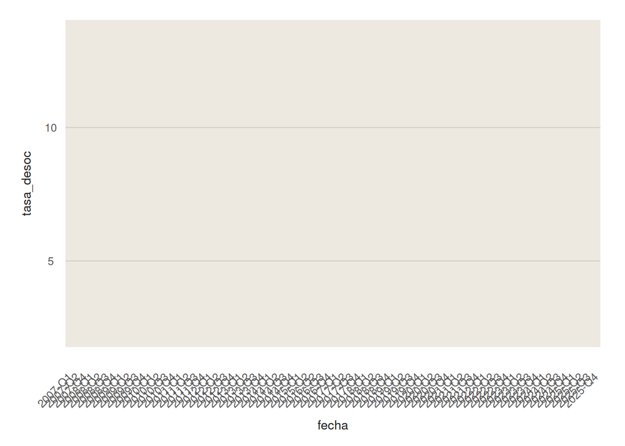

```r
ggplot(df, aes(x = fecha, y = tasa_desoc))
```

## Paso 2 - agregamos la geometría

`geom_line()` = la marca. Una línea (1D).

Mirá el resultado antes de seguir.

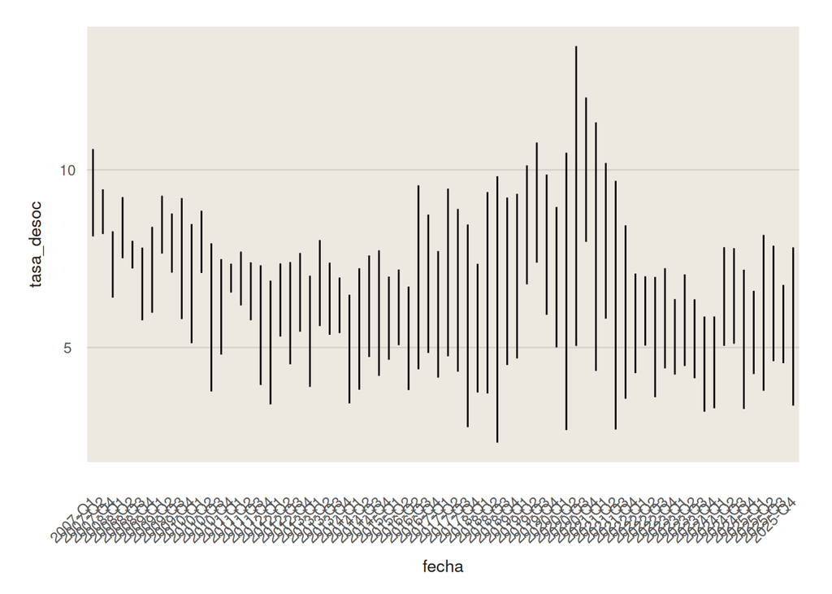

```r
ggplot(df, aes(x = fecha, y = tasa_desoc)) +
  geom_line()
```

## Paso 3 - le decimos dónde cortar la línea

`group` le dice a ggplot que hay TRES series, no una. Sin esto, une todos los puntos en el orden del eje x, saltando de una región a otra.

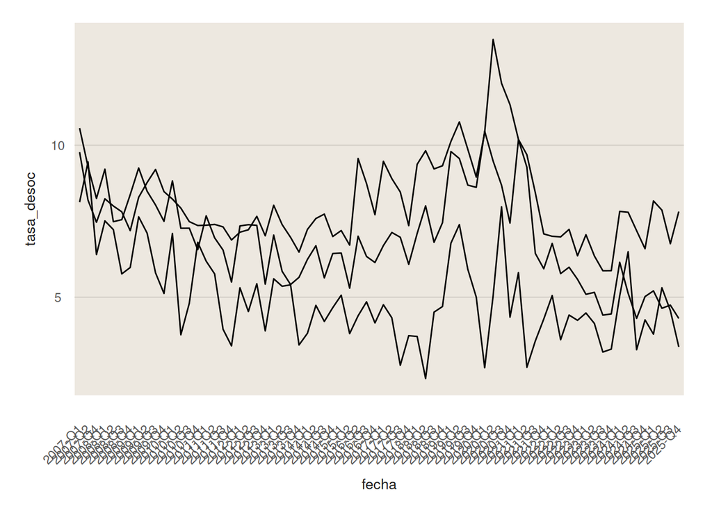

```r
ggplot(df, aes(x = fecha, y = tasa_desoc,
               group = la_rioja_region)) +
  geom_line()
```

## Paso 4 - mapeamos la región al color

Ahora la región está codificada en DOS canales: agrupamiento y matiz.

**Atención** a la diferencia: `color = la_rioja_region` va **dentro** de `aes()` (depende del dato); `linewidth = 0.7` va **fuera** (es una constante). Confundir esto es el error nº1 de quien arranca con ggplot. Probá poner `linewidth` adentro de `aes()` y mirá qué pasa con la leyenda.

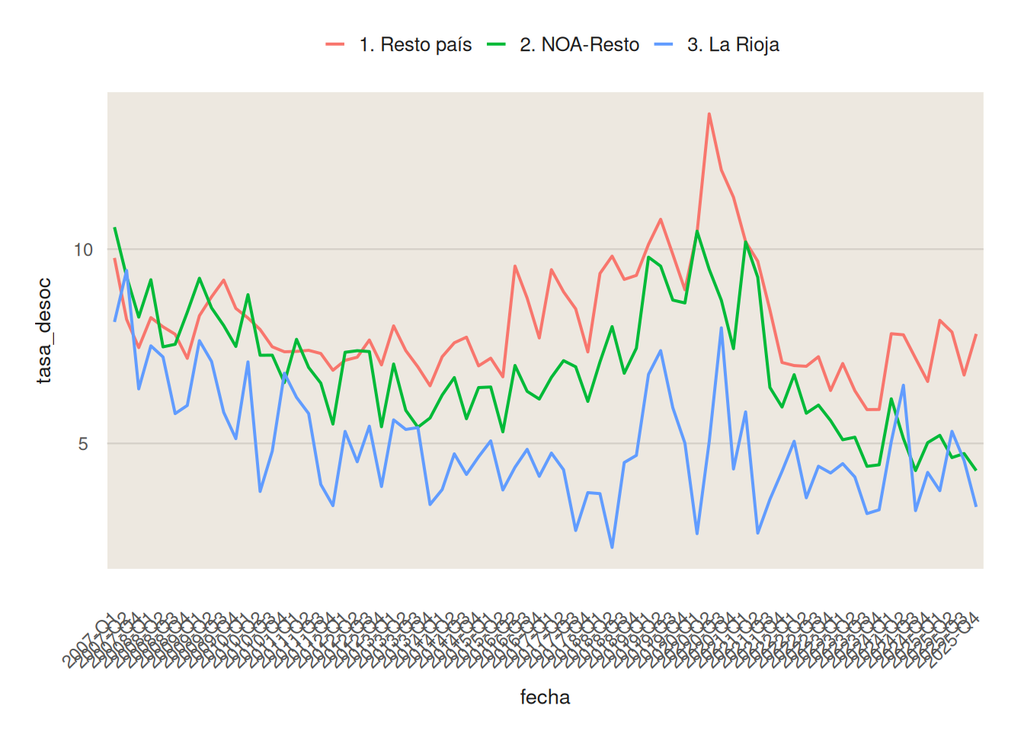

```r
ggplot(df, aes(x = fecha, y = tasa_desoc,
               group = la_rioja_region,
               color = la_rioja_region)) +
  geom_line(linewidth = 0.7)
```

## Paso 5 - la escala del proyecto

Hasta acá ggplot eligió los colores solo. `scale_color_fundar_multi()` impone la paleta institucional: dos tonos claros para el resto y el teal oscuro para La Rioja.

**Pregunta:** ¿cuánto tardás en encontrar La Rioja antes y después de esta línea?

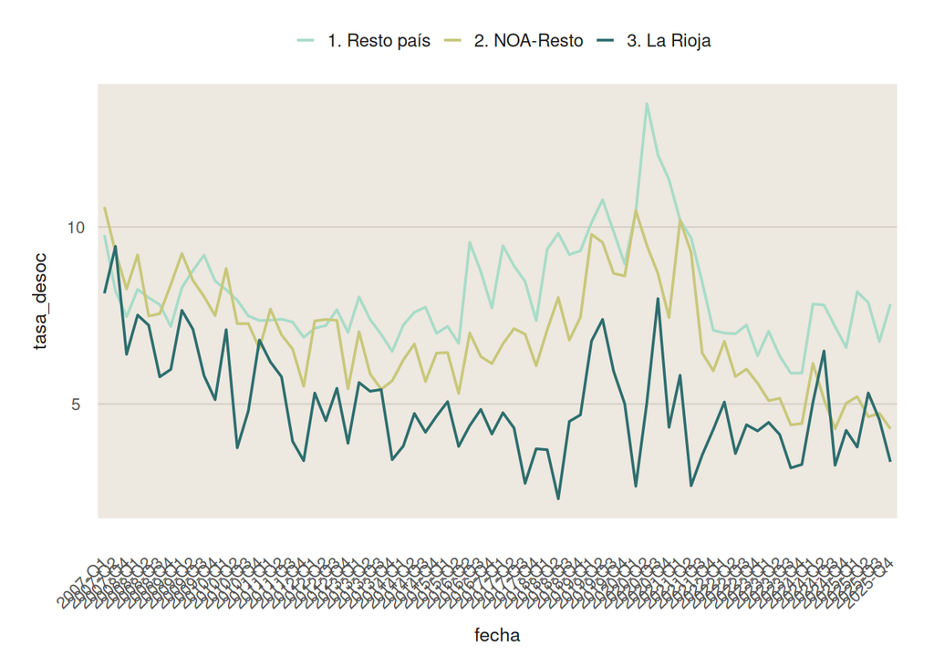

```r
ggplot(df, aes(x = fecha, y = tasa_desoc,
               group = la_rioja_region,
               color = la_rioja_region)) +
  geom_line(linewidth = 0.7) +
  scale_color_fundar_multi(name = "Región")
```

## Paso 6 - el tema

`theme_monitor()` no toca NINGÚN dato: solo decide cómo se ve lo que no es dato (fondo, grilla, tipografía, posición de la leyenda). Por eso vive en un archivo aparte y se aplica igual a los diez indicadores del monitor.

`ylim(0, 20)` sí es una escala: fuerza que el eje y arranque en cero.

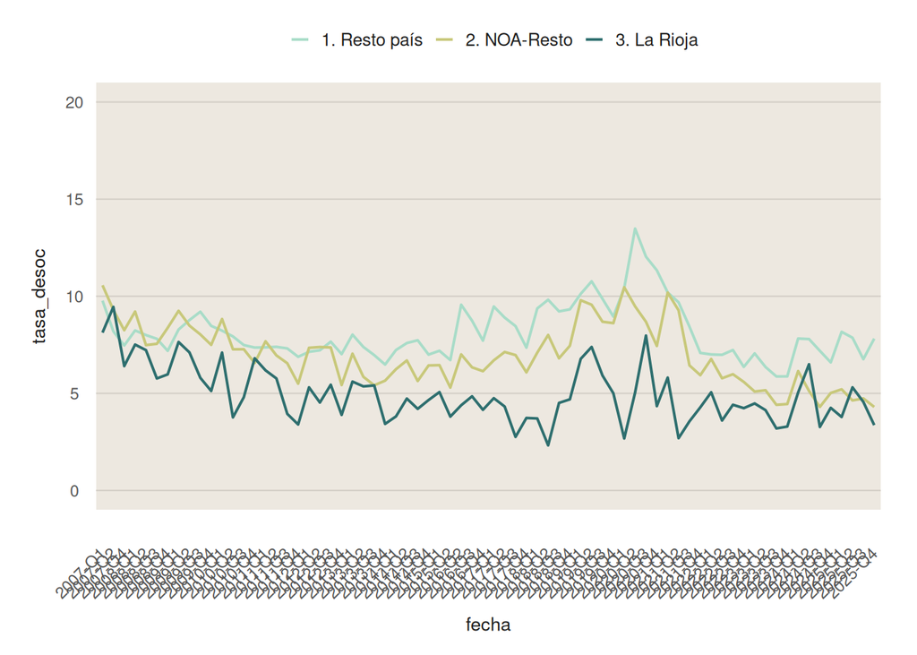

```r
ggplot(df, aes(x = fecha, y = tasa_desoc,
               group = la_rioja_region,
               color = la_rioja_region)) +
  geom_line(linewidth = 0.7) +
  scale_color_fundar_multi(name = "Región") +
  ylim(0, 20) +
  theme_monitor()
```

## Paso 7 - la anotación

Título, ejes y fuente. Esto es lo que separa un gráfico de exploración de un gráfico publicable. Volvemos sobre cómo redactarlos en la clase 3.

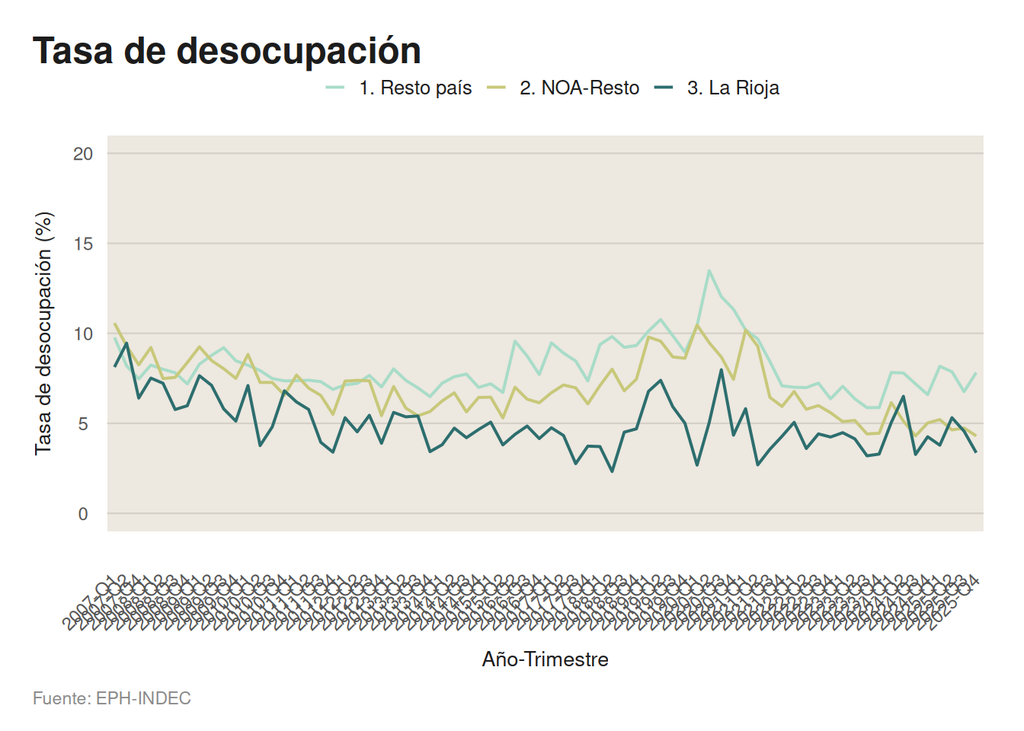

```r
ggplot(df, aes(x = fecha, y = tasa_desoc,
               group = la_rioja_region,
               color = la_rioja_region)) +
  geom_line(linewidth = 0.7) +
  scale_color_fundar_multi(name = "Región") +
  ylim(0, 20) +
  theme_monitor() +
  labs(title   = "Tasa de desocupación",
       x       = "Año-Trimestre",
       y       = "Tasa de desocupación (%)",
       caption = fuente_fundar("EPH-INDEC"))
```

Llegamos exactamente a `src/04_desoc.R`. Abrilo y comparalo.

## Cómo se generó el tema de La Rioja

`theme_monitor()` y `scale_color_fundar_multi()` no salieron de la nada. Vale la pena abrir `style/fundar_monitor_theme.R` una vez y ver de dónde sale cada decisión.

### Dónde vive y cómo se carga

El tema es **un único archivo R**, `style/fundar_monitor_theme.R` (312 líneas), en la raíz del repo, fuera de `src/` y de `clases/`. No es un paquete ni se instala: es texto plano que se trae con `source()`. Así lo hicimos arriba, en el chunk de setup de este mismo documento:

```r
source("../../style/fundar_monitor_theme.R")
```

Cualquier script de `src/` empieza igual (con la ruta relativa a la raíz del repo, porque corren desde `fundar_larioja.Rproj`). `source()` ejecuta el archivo entero, lo que define las paletas, las funciones `scale_*` y `theme_monitor()` en el entorno global, y además hace una cosa más: la última línea antes del mensaje de confirmación es

```r
theme_set(theme_monitor())
```

Eso vuelve `theme_monitor()` el tema **por defecto de la sesión**: todo `ggplot()` que se dibuje de ahí en adelante lo usa aunque no se agregue `+ theme_monitor()` explícitamente. En los ejercicios igual lo escribimos explícito, por claridad - pero si un gráfico del repo se ve “temeado” sin que el script lo diga, es por esto.

**El archivo no se genera solo: se escribe y edita a mano.** No hay ningún script que lo produzca ni lo regenere - es la fuente de verdad, versionada en git como cualquier otro `.R`. Lo único que se *deriva* de él es un artefacto de documentación, `clases/materiales/paleta_regional_swatch.R`, que lee los tres hex de `FUNDAR_MULTI` (sin copiarlos) y arma un PNG de referencia en `outputs/plots/paleta_regional_la_rioja.png`. Si alguien cambia un color en el tema, ese swatch se actualiza solo la próxima vez que se corre - no hay que tocar dos archivos a mano.

### Qué replica: la identidad del Monitor de Empresas

El tema no se diseñó desde cero: reproduce el estilo del [Monitor Mensual de Empresas](https://fund.ar/publicacion/monitor-mensual-de-empresas/) de Fundar (`style/fundar_monitor_theme.R:1-5`). Adoptar una identidad existente en vez de inventar una nueva es lo que permite que el Monitor de La Rioja se lea como parte de la misma familia de publicaciones. De ahí salen los colores institucionales base (`style/fundar_monitor_theme.R:16-22`):

| Constante | Hex | Uso |
| --- | --- | --- |
| `FUNDAR_VERDE` | `#52C8A0` | color principal / valores positivos |
| `FUNDAR_ROSA` | `#F4877A` | valores negativos / caídas |
| `FUNDAR_BEIGE` | `#EDE8E0` | fondo del área de gráfico |
| `FUNDAR_OSCURO` | `#1C1C1C` | fondo oscuro (slides de KPIs) |
| `FUNDAR_GRIS` | `#888888` | texto secundario, subtítulos |
| `FUNDAR_GRILLA` | `#D5D0C8` | líneas de grilla horizontales |
| `FUNDAR_TEXTO` | `#1C1C1C` | texto principal |

### La paleta regional: dos decisiones deliberadas

`FUNDAR_MULTI` (`style/fundar_monitor_theme.R:25-31`) extiende esos colores institucionales a cinco tonos para poder distinguir series. El monitor de La Rioja usa tres - uno por región - y ahí aparece la decisión de diseño central de la clase de hoy:

```r
FUNDAR_MULTI <- c(
  "serie_1" = "#A8DCC8",   # Verde menta claro    → 1. Resto país
  "serie_2" = "#C8C87A",   # Amarillo oliva       → 2. NOA-Resto
  "serie_3" = "#2D6E6E",   # Verde azulado oscuro → 3. La Rioja (énfasis)
  ...
```

Esto no es una elección estética libre, son dos decisiones deliberadas:

- **Saliencia por contraste de luminancia.** “Resto país” y “NOA-Resto” son tonos claros y de baja saturación; La Rioja es el único color oscuro y saturado de los tres. Es la misma idea de *pop-out* que vimos en la teoría: la serie protagonista salta a la vista sin que el lector tenga que buscarla. Ese contraste se podría auditar con números -diferencia de luminancia en espacio Lab, distancia perceptual ΔE, y simulación de daltonismo con `colorspace`- para confirmar que sobrevive incluso a visión con deuteranopia o protanopia, porque la luminancia no depende del canal cromático (`src/test_escalas.R` es un intento a medio hacer de esa auditoría).
- **El orden de los niveles no es cosmético.** Los prefijos `"1."`, `"2."`, `"3."` fuerzan el orden alfabético del factor `la_rioja_region` (definido en `src/utils_eph.R`), y con eso el orden en que ggplot dibuja las capas: La Rioja se dibuja última y queda por encima de las otras dos regiones cuando las líneas se cruzan.

`FUNDAR_SECTOR` (`style/fundar_monitor_theme.R:33-39`) hace algo parecido a menor escala: para el indicador de salarios EPH público/privado, reutiliza dos colores ya definidos -“Resto país” para Privado, “NOA-Resto” para Público- en vez de inventar un par nuevo. Menos colores distintos circulando en el monitor, más fácil de recordar qué significa cada uno.

### El tema base: qué decide `theme_monitor()`

Además de la paleta, `theme_monitor()` (`style/fundar_monitor_theme.R:72-135`) toma una serie de decisiones sobre “todo lo que no es dato”, partiendo de `theme_minimal()` y sobreescribiendo:

- **Fondo:** el área del gráfico tiene fondo beige (`FUNDAR_BEIGE`) por defecto -parámetro `fondo_beige = TRUE`-, para separarla visualmente del fondo blanco de la página.
- **Grilla:** solo horizontal (`panel.grid.major.y`), muy suave, y **nada de grilla vertical ni menor**. La grilla ayuda a leer valores en el eje y; en el eje x alcanza con los ticks.
- **Ejes:** sin marcas de tick (`axis.ticks = element_blank()`) ni línea de eje; las etiquetas del eje x van a 45° para no solaparse.
- **Leyenda:** arriba (`legend.position = "top"`) y horizontal, sin título ni caja - a diferencia de una leyenda lateral clásica, prioriza que el lector la vea antes de mirar el gráfico.
- **Títulos:** título en negrita alineado a la izquierda, subtítulo gris debajo, y fuente (`plot.caption`) chica y gris abajo a la izquierda -`fuente_fundar()`, ver más abajo-.

Todos estos son parámetros de la función (`base_size`, `legend_position`, `fondo_beige`): se puede ajustar el tamaño de fuente o mover la leyenda sin tocar el archivo, pasando argumentos.

### No es un solo tema: hay variantes

El archivo define tres funciones de tema, todas construidas **encima** de `theme_monitor()` con `%+replace%` (no la reescriben desde cero):

- `theme_monitor()` - la default, fondo beige claro.
- `theme_monitor_oscuro()` (`:138-157`) - fondo `FUNDAR_OSCURO`, texto claro. Pensado para slides de KPIs o portada, no para el cuerpo del informe.
- `theme_monitor_barras_h()` (`:161-170`) - para barras horizontales: invierte la grilla (vertical en vez de horizontal, para poder leer los valores de las barras) y ajusta el tamaño de las etiquetas del eje y.

### Funciones helper que vienen con el archivo

El archivo no es solo un tema visual, también trae funciones de conveniencia para no repetir código en los diez scripts de `src/`:

- `fuente_fundar(texto)` - antepone `"Fuente: "` al texto de la cita, para no tipearlo cada vez.
- `puntos_etiqueta(data, var_x, var_y, var_grupo)` - devuelve las filas de máximo, mínimo y último valor por grupo, listas para pasarle a `geom_text()`/`geom_label()`.
- `grafico_linea_monitor(...)` y `grafico_barras_div(...)` - arman de punta a punta el gráfico de línea simple o de barras divergentes en el estilo del Monitor, para los casos más comunes.

### La relación con el tema anterior

Existe un tema previo, `style/fundar_larioja_theme.R`, con su propia paleta (`COLORES_REGION`) y su propio `theme_la_rioja()`. Fue el primer diseño, anterior a la decisión de alinear todo el monitor con la identidad visual del Monitor Mensual de Empresas. El tema vigente -el que usamos en toda esta práctica- es `style/fundar_monitor_theme.R`; el archivo viejo queda en el repo como referencia histórica, no se usa en los scripts de `src/`.

En síntesis: el tema no fija solo “qué colores se ven lindos”, fija **qué serie tiene que ganar la atención del lector primero**, y lo hace desde un único archivo fuente que se carga con `source()` al principio de cada script. Eso es exactamente lo que vamos a poner a prueba en el ejercicio 3.

## Extra

El eje x tiene 72 etiquetas de texto a 45°: es ilegible. Pasa porque `fecha` es un string (`"2007-Q1"`) y ggplot trata cada valor como una categoría. Convirtiéndolo a fecha real, ggplot puede elegir marcas cada N años. (Esto lo retomamos en la clase 2 como caso de “visual cluttering”.)

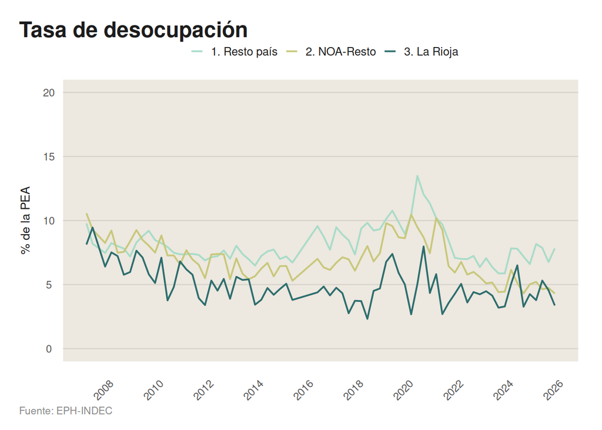

```r
df %>%
  mutate(fecha = lubridate::yq(fecha)) %>%
  ggplot(aes(x = fecha, y = tasa_desoc,
             group = la_rioja_region, color = la_rioja_region)) +
  geom_line(linewidth = 0.7) +
  scale_color_fundar_multi(name = "Región") +
  scale_x_date(date_labels = "%Y", date_breaks = "2 years") +
  ylim(0, 20) +
  theme_monitor() +
  labs(title = "Tasa de desocupación", x = NULL, y = "% de la PEA",
       caption = fuente_fundar("EPH-INDEC"))
```

# Ejercicio 2 - Tres mapeos del mismo dato (15’)

`data/inputs_md/13a_nbi_hogares.csv` tiene, para cada trimestre y cada región, el porcentaje de hogares con NBI **total** y también las **cinco sub-dimensiones**: hacinamiento (`HAC`), vivienda inconveniente (`VIV`), condiciones sanitarias (`SAN`), escolaridad (`ESC`) y capacidad de subsistencia (`SUB`).

Hoy `src/13a_nbi_hogares.R` grafica **solo el total**, con una línea por región. Las cinco sub-dimensiones están calculadas y no se muestran en ningún lado.

Tenés tres versiones del mismo dato para completar:

- **Versión A** - color = dimensión, un panel por región.
- **Versión B** - color = región, un panel por dimensión.
- **Versión C** - todo superpuesto en un solo panel: color = región, tipo de línea = dimensión.

**La consigna no es “cuál es la más linda”, es “a qué pregunta responde mejor cada una”.** Anotá, para cada versión, una pregunta que se conteste bien mirándola:

| Versión | ¿Qué pregunta contesta bien? | ¿Qué pregunta contesta mal? |
| --- | --- | --- |
| A |  |  |
| B |  |  |
| C |  |  |

Pistas de discusión:

- ¿Cuál sirve para “¿qué privación pesa más en La Rioja?”
- ¿Cuál sirve para “¿La Rioja está mejor o peor que el NOA en hacinamiento?”
- La versión C usa **dos canales a la vez** (matiz y tipo de línea) sobre la misma marca. Mirando la slide 37 del deck, ¿son separables? ¿Cuántas series terminás viendo?

## Datos

```r
df <- read_csv("../../data/inputs_md/13a_nbi_hogares.csv", show_col_types = FALSE)

glimpse(df)
```

```
## Rows: 213
## Columns: 15
## $ fecha               <chr> "2007-Q1", "2007-Q1", "2007-Q1", "2007-Q2", "2007-…
## $ la_rioja_region     <chr> "1. Resto país", "2. NOA-Resto", "3. La Rioja", "1…
## $ hogares_NBI_TOT     <dbl> 510017, 67448, 4373, 472674, 65434, 4381, 450642, …
## $ hogares_NBI_HAC     <dbl> 316119, 46159, 2509, 293479, 42455, 3346, 286566, …
## $ hogares_NBI_VIV     <dbl> 46941, 6460, 808, 48216, 6357, 150, 42226, 7969, 3…
## $ hogares_NBI_SAN     <dbl> 53670, 17309, 563, 59145, 17605, 534, 46599, 21277…
## $ hogares_NBI_ESC     <dbl> 18908, 1448, 131, 13691, 1457, 0, 17879, 1544, 153…
## $ hogares_NBI_SUB     <dbl> 111604, 8368, 601, 95937, 7921, 711, 90613, 9196, …
## $ hogares_base        <dbl> 6712696, 526458, 43182, 6825309, 533015, 42724, 67…
## $ pct_hogares_NBI_TOT <dbl> 7.597797, 12.811658, 10.126905, 6.925313, 12.27620…
## $ pct_hogares_NBI_HAC <dbl> 4.709270, 8.767841, 5.810291, 4.299864, 7.965067, …
## $ pct_hogares_NBI_VIV <dbl> 0.6992868, 1.2270684, 1.8711500, 0.7064296, 1.1926…
## $ pct_hogares_NBI_SAN <dbl> 0.7995297, 3.2878216, 1.3037840, 0.8665542, 3.3029…
## $ pct_hogares_NBI_ESC <dbl> 0.28167520, 0.27504568, 0.30336714, 0.20059165, 0.…
## $ pct_hogares_NBI_SUB <dbl> 1.6625809, 1.5894905, 1.3917836, 1.4056067, 1.4860…
```

```r
# pct_hogares_NBI_TOT + pct_hogares_NBI_{HAC, VIV, SAN, ESC, SUB}
```

## Preparación: de formato ancho a formato largo

ggplot necesita UNA fila por (trimestre, región, dimensión). Hoy las dimensiones son 6 columnas distintas: hay que apilarlas. (Este paso -`pivot_longer`- es el 80% del trabajo de preparar datos para graficar. Vale la pena leerlo con calma.)

```r
df_largo <- df %>%
  select(fecha, la_rioja_region, starts_with("pct_hogares_NBI_")) %>%
  pivot_longer(
    cols      = starts_with("pct_hogares_NBI_"),
    names_to  = "dimension",
    values_to = "pct"
  ) %>%
  mutate(
    dimension = str_remove(dimension, "pct_hogares_NBI_"),
    dimension = recode(dimension,
                       TOT = "Total",
                       HAC = "Hacinamiento",
                       VIV = "Vivienda",
                       SAN = "Sanitarias",
                       ESC = "Escolaridad",
                       SUB = "Subsistencia"),
    fecha = lubridate::yq(fecha)   # a fecha real, para que el eje x respire
  ) %>%
  filter(dimension != "Total")     # las 5 sub-dimensiones; el total ya se grafica

glimpse(df_largo)
```

```
## Rows: 1,065
## Columns: 4
## $ fecha           <date> 2007-01-01, 2007-01-01, 2007-01-01, 2007-01-01, 2007-…
## $ la_rioja_region <chr> "1. Resto país", "1. Resto país", "1. Resto país", "1.…
## $ dimension       <chr> "Hacinamiento", "Vivienda", "Sanitarias", "Escolaridad…
## $ pct             <dbl> 4.7092703, 0.6992868, 0.7995297, 0.2816752, 1.6625809,…
```

## Versión A - color = dimensión, un panel por región

**Completá el `aes()` y el `facet_wrap()`**

- `color` debe mapear a `dimension`
- el facetado debe partir por `la_rioja_region`

```r
###
```

**Pregunta:** mirando el panel de La Rioja, ¿podés decir qué privación pesa más?

## Versión B - color = región, un panel por dimensión

**TODO:** es la versión A dada vuelta. Cambiá qué va al color y qué al facet. Usá `scale_color_fundar_multi()` para que La Rioja se destaque.

```r
###
```

**Preguntas:**

- ¿Podés decir si La Rioja está mejor o peor que el NOA en hacinamiento? ¿Y en la versión A?
- `scales = "free_y"` hace que cada panel tenga su propia escala. ¿Qué se gana y qué se pierde con eso?

## Versión C - todo superpuesto: color = región, linetype = dimensión

Sin facetado: dos canales sobre la misma marca, en un solo panel.

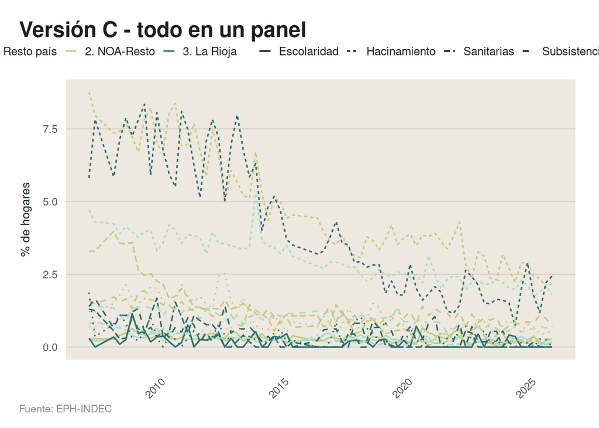

```r
df_largo %>%
  ggplot(aes(x = fecha, y = pct,
             group    = interaction(la_rioja_region, dimension),
             color    = la_rioja_region,
             linetype = dimension)) +
  geom_line(linewidth = 0.6) +
  scale_color_fundar_multi(name = "Región") +
  theme_monitor() +
  labs(title = "Versión C - todo en un panel",
       x = NULL, y = "% de hogares",
       caption = fuente_fundar("EPH-INDEC"))
```

**Preguntas:**

- ¿Cuántas series hay dibujadas? (contá: regiones × dimensiones)
- Mirando la slide 37 del deck: matiz + tipo de línea, ¿son separables?
- ¿Podés seguir UNA serie de punta a punta?

## Para la puesta en común

Completá:

| Versión | ¿Qué pregunta contesta BIEN? | ¿Qué pregunta contesta MAL? |
| --- | --- | --- |
| A |  |  |
| B |  |  |
| C |  |  |

# Ejercicio 3 - Romper el gráfico a propósito (10’)

Este ejercicio es para **comprobar en carne propia** la jerarquía de canales que vimos en la teoría.

Tomá el gráfico de la tasa de empleo (`data/inputs_md/10_tasa_empleo.csv`) y hacé tres versiones donde la región se codifique con canales distintos:

- **A** - con `color` (el canal que usa el repo).
- **B** - con `shape` (forma del punto).
- **C** - con `size` (grosor de línea).

Después, para cada una, contestá lo más honestamente posible:

1. ¿Cuánto tardás en encontrar la serie de **La Rioja**?
2. Si dos series se cruzan, ¿podés seguirlas?
3. ¿Podrías distinguir seis series en vez de tres con ese canal?

**Bonus (2’):** en la versión A, cambiá la paleta del proyecto por una donde las tres regiones tengan la **misma luminancia** (el chunk de bonus trae una preparada). La Rioja deja de saltar a la vista. Ese es, exactamente, el efecto que la paleta del proyecto está diseñada para producir.

## Datos

```r
df <- read_csv("../../data/inputs_md/10_tasa_empleo.csv", show_col_types = FALSE) %>%
  mutate(fecha = lubridate::yq(fecha))
```

## Versión A - región mapeada a COLOR (matiz + luminancia)

Es lo que hace el repo.

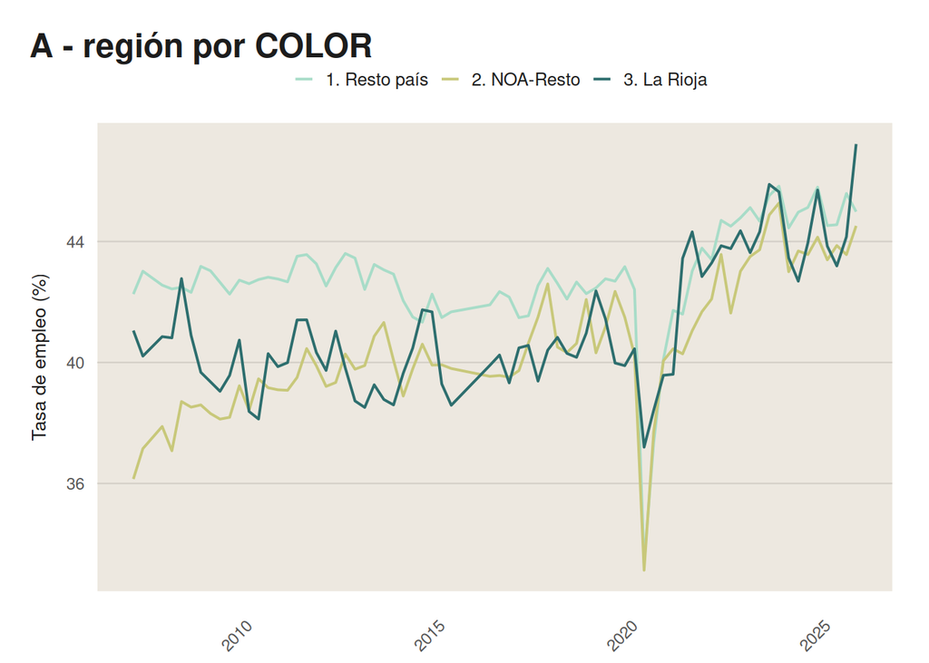

```r
df %>%
  ggplot(aes(x = fecha, y = tasa_empleo,
             group = la_rioja_region,
             color = la_rioja_region)) +
  geom_line(linewidth = 0.7) +
  scale_color_fundar_multi(name = "Región") +
  theme_monitor() +
  labs(title = "A - región por COLOR", x = NULL, y = "Tasa de empleo (%)")
```

**Cronometrate:** ¿cuánto tardás en encontrar la serie de La Rioja?

## Versión B - región mapeada a FORMA del punto

La forma es, según Munzner, el PEOR canal para variables categóricas. Necesitamos puntos (la forma no se puede aplicar a una línea).

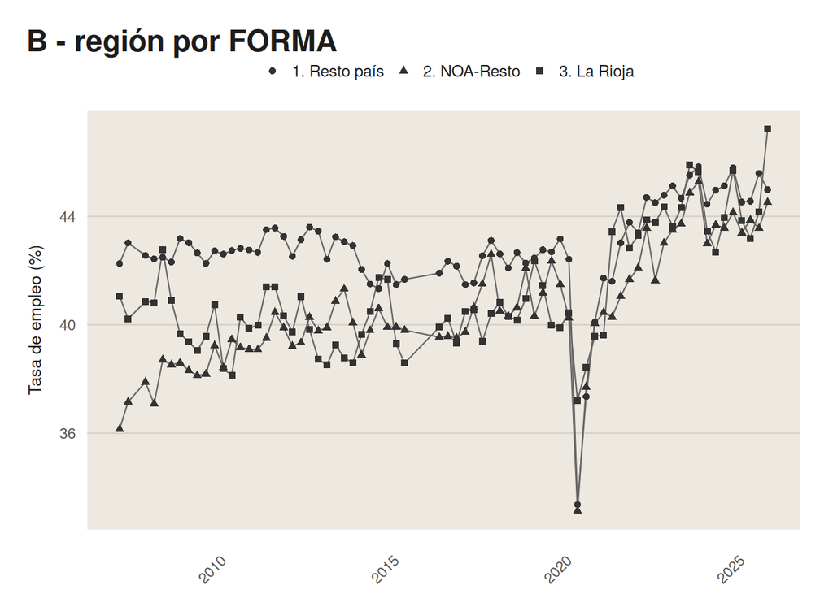

```r
df %>%
  ggplot(aes(x = fecha, y = tasa_empleo,
             group = la_rioja_region,
             shape = la_rioja_region)) +
  geom_line(linewidth = 0.4, color = "grey40") +
  geom_point(size = 1.6, color = "grey20") +
  theme_monitor() +
  labs(title = "B - región por FORMA", x = NULL, y = "Tasa de empleo (%)")
```

**Preguntas:**

- ¿Cuánto tardás ahora en encontrar La Rioja?
- Donde dos series se cruzan, ¿podés seguirlas?
- ¿Distinguirías SEIS regiones con este canal?

## Versión C - región mapeada a TAMAÑO (grosor de línea)

El tamaño tiene ordinalidad implícita: sugiere que una categoría es “más” que otra. Para una variable puramente categórica, eso es información falsa.

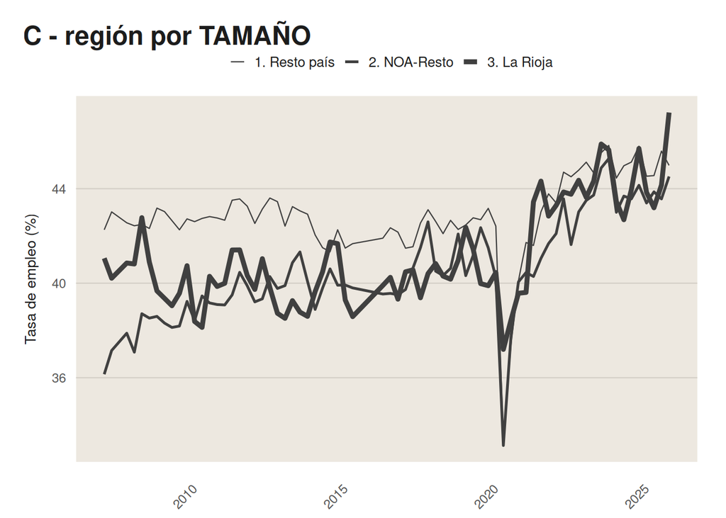

```r
df %>%
  ggplot(aes(x = fecha, y = tasa_empleo,
             group     = la_rioja_region,
             linewidth = la_rioja_region)) +
  geom_line(color = "grey25") +
  scale_linewidth_manual(values = c(0.4, 0.9, 1.6), name = "Región") +
  theme_monitor() +
  labs(title = "C - región por TAMAÑO", x = NULL, y = "Tasa de empleo (%)")
```

**Pregunta:** ¿qué te sugiere que “3. La Rioja” sea la línea más gruesa? ¿Es información que está en los datos o la agregó el gráfico?

## Bonus - la misma paleta, sin contraste de luminancia

Volvemos a la versión A, pero con tres colores de LUMINANCIA PAREJA. El matiz sigue distinguiendo las regiones… pero La Rioja deja de saltar a la vista.

Ese contraste es exactamente lo que la paleta del proyecto está diseñada para producir (ver `style/fundar_monitor_theme.R:25-31`).

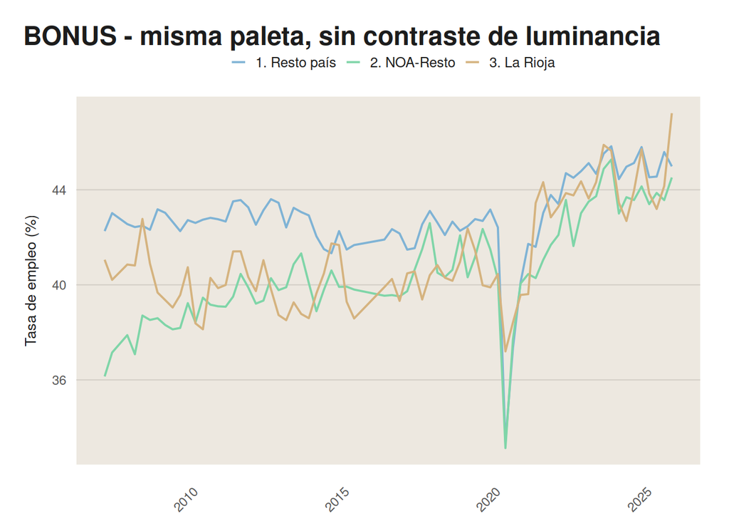

```r
PALETA_PLANA <- c("#7FB3D5", "#7FD5A8", "#D5B37F")   # tres tonos, misma luminancia

df %>%
  ggplot(aes(x = fecha, y = tasa_empleo,
             group = la_rioja_region,
             color = la_rioja_region)) +
  geom_line(linewidth = 0.7) +
  scale_color_manual(values = PALETA_PLANA, name = "Región") +
  theme_monitor() +
  labs(title = "BONUS - misma paleta, sin contraste de luminancia",
       x = NULL, y = "Tasa de empleo (%)")
```

**Pregunta final:** compará esta con la versión A. ¿Cuál usarías en un informe donde el protagonista es La Rioja? ¿Y en uno que compara las tres regiones en pie de igualdad?

# Puesta en común (10’)

Traé a la puesta en común:

- Del ejercicio 2: tu tabla de “qué pregunta contesta cada versión”.
- Del ejercicio 3: en cuál de las tres versiones tardaste más en encontrar La Rioja.